# RStudio Exercise 2 - Analysis

### Task 1

**Task** *Read the students2014 data into R either from your local folder (if you completed the Data wrangling part) or from this url: http://s3.amazonaws.com/assets.datacamp.com/production/course_2218/datasets/learning2014.txt . (The separator is a comma “,” and the file includes a header). Explore the structure and the dimensions of the data and describe the dataset briefly, assuming the reader has no previous knowledge of it. There is information related to the data here.*

```r
students2014 <- read.table("http://s3.amazonaws.com/assets.datacamp.com/production/course_2218/datasets/learning2014.txt",sep=",",header=TRUE)
```

```r
dim(students2014)
```

```
## [1] 166   7
```

```r
str(students2014)
```

```
## 'data.frame':    166 obs. of  7 variables:
##  $ gender  : Factor w/ 2 levels "F","M": 1 2 1 2 2 1 2 1 2 1 ...
##  $ age     : int  53 55 49 53 49 38 50 37 37 42 ...
##  $ attitude: num  3.7 3.1 2.5 3.5 3.7 3.8 3.5 2.9 3.8 2.1 ...
##  $ deep    : num  3.58 2.92 3.5 3.5 3.67 ...
##  $ stra    : num  3.38 2.75 3.62 3.12 3.62 ...
##  $ surf    : num  2.58 3.17 2.25 2.25 2.83 ...
##  $ points  : int  25 12 24 10 22 21 21 31 24 26 ...
```

Data frame students2014 includes 166 items and 7 variables. Variabels and their types have been listed above.

### Task 2

**Task** *Show a graphical overview of the data and show summaries of the variables in the data. Describe and interpret the outputs, commenting on the distributions of the variables and the relationships between them.*

```r
attach(students2014)
```

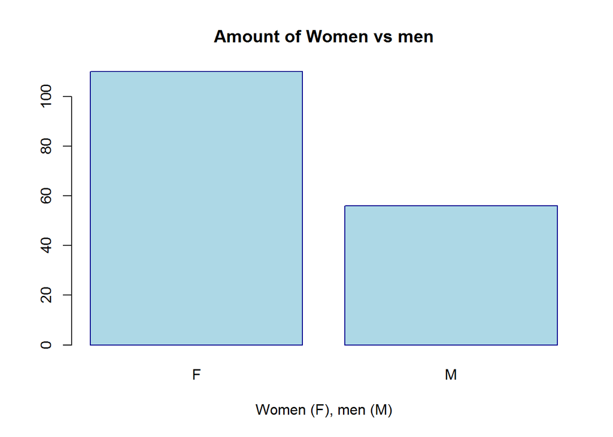

```r
plot(gender, border="dark blue", col="light blue", main="Amount of Women vs men", xlab="Women (F), men (M)")
```

```r
summary(gender)
```

```
##   F   M
## 110  56
```

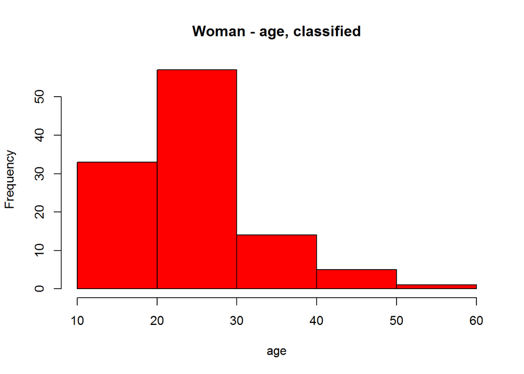

```r
Nika <- subset(age, (gender == "F"))
hist(Nika, col="red", breaks=c(10,20,30,40,50,60), main="Woman - age, classified", xlab="age")
```

```r
summary(Nika)
```

```
##    Min. 1st Qu.  Median    Mean 3rd Qu.    Max.
##   17.00   20.00   22.00   24.85   26.00   53.00
```

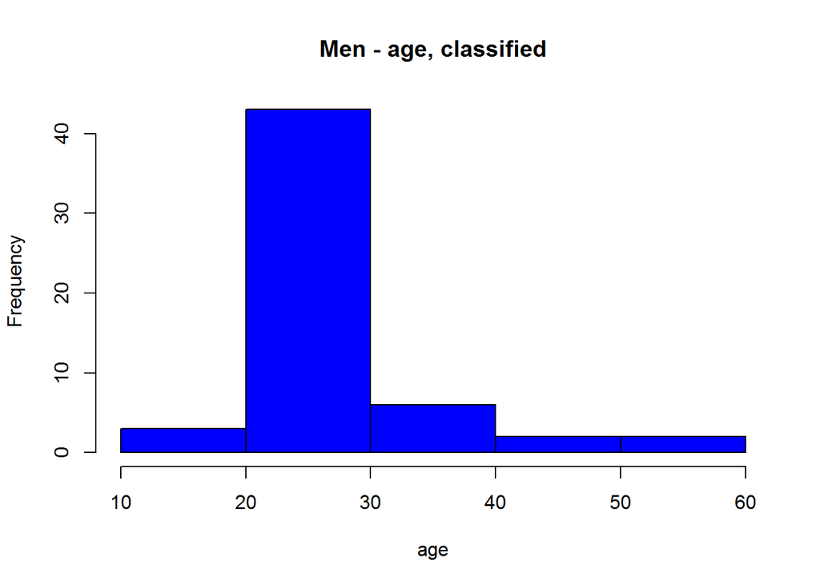

```r
Mika <- subset(age, (gender == "M"))
hist(Mika, col="blue", breaks=c(10,20,30,40,50,60), main="Men - age, classified", xlab="age")
```

```r
summary(Mika)
```

```
##    Min. 1st Qu.  Median    Mean 3rd Qu.    Max.
##    19.0    21.0    24.0    26.8    29.0    55.0
```

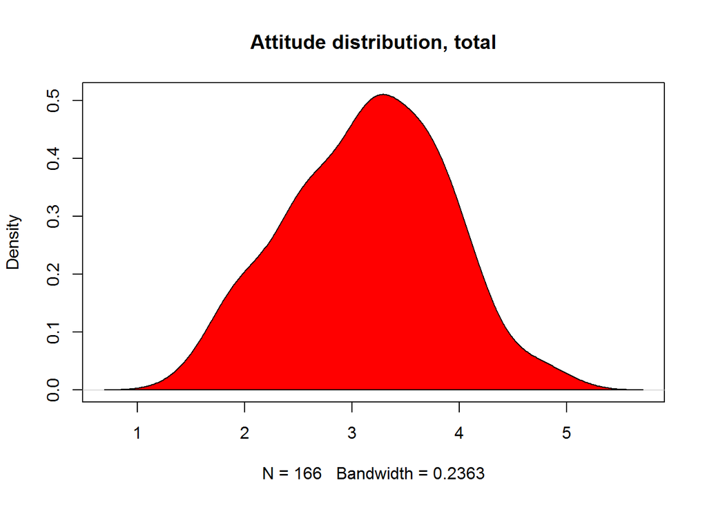

```r
d <- density(students2014$attitude)
plot(d, main="Attitude distribution, total")
polygon(d, col="red", border="black")
```

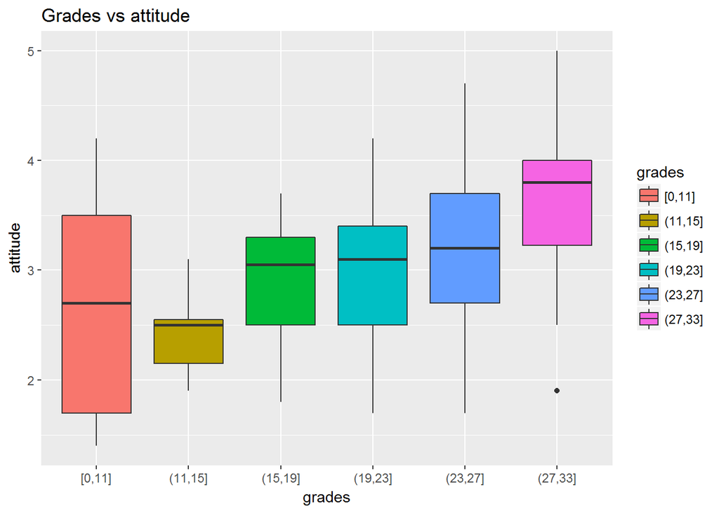

```r
library(ggplot2)
grades <- cut(students2014$points, breaks = c(0, 11, 15, 19, 23, 27, 33), include.lowest = TRUE)
qplot(grades, attitude, data=students2014, geom="boxplot", fill=grades, main="Grades vs attitude")
```

```r
summary(students2014$attitude)
```

```
##    Min. 1st Qu.  Median    Mean 3rd Qu.    Max.
##   1.400   2.600   3.200   3.143   3.700   5.000
```

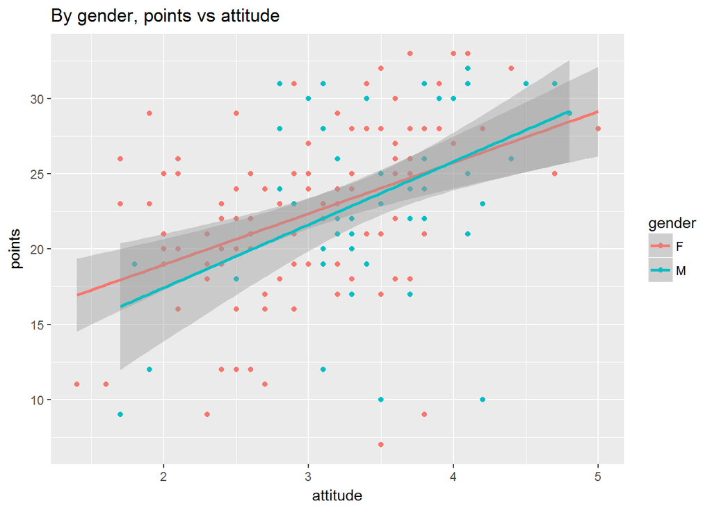

```r
qplot(attitude, points, col = gender, main = "By gender, points vs attitude", data = students2014) + geom_smooth(method = "lm")
```

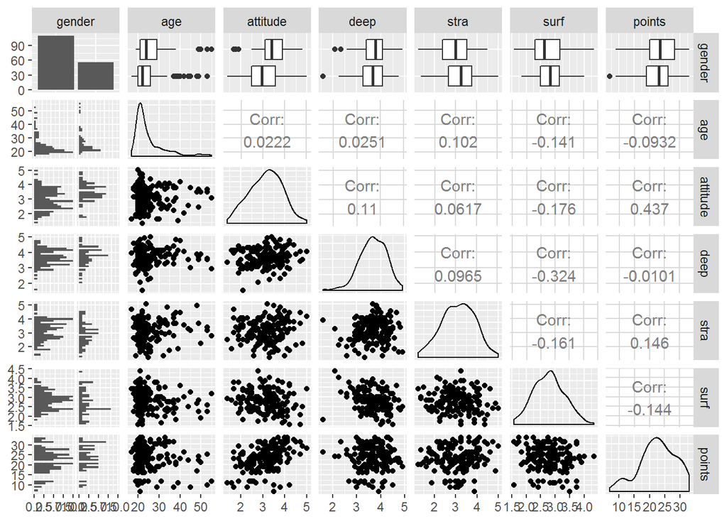

```r
library(GGally)
ggpairs(students2014)
```

### Task 3  
**Task** *Choose three variables as explanatory variables and fit a regression model where exam points is the target (dependent) variable. Show a summary of the fitted model and comment and interpret the results. Explain and interpret the statistical test related to the model parameters. If an explanatory variable in your model does not have a statistically significant relationship with the target variable, remove the variable from the model and fit the model again without it.*  
We’ll get three explanatory variables from last picture in the previous section. Three variables that correlates most with exam points are attitude (0.437), stra (0.146) and surf (-0.144).

```r
model1 <- lm(points ~ attitude + stra + surf, data=students2014)
summary(model1)
```

```
##
## Call:
## lm(formula = points ~ attitude + stra + surf, data = students2014)
##
## Residuals:
##      Min       1Q   Median       3Q      Max
## -17.1550  -3.4346   0.5156   3.6401  10.8952
##
## Coefficients:
##             Estimate Std. Error t value Pr(>|t|)
## (Intercept)  11.0171     3.6837   2.991  0.00322 **
## attitude      3.3952     0.5741   5.913 1.93e-08 ***
## stra          0.8531     0.5416   1.575  0.11716
## surf         -0.5861     0.8014  -0.731  0.46563
## ---
## Signif. codes:  0 '***' 0.001 '**' 0.01 '*' 0.05 '.' 0.1 ' ' 1
##
## Residual standard error: 5.296 on 162 degrees of freedom
## Multiple R-squared:  0.2074, Adjusted R-squared:  0.1927
## F-statistic: 14.13 on 3 and 162 DF,  p-value: 3.156e-08
```

Variable surf’s p-value 0.46563 is much greater than 0.05 so we drop it from model.

```r
model2 <- lm(points ~ attitude + stra)
summary(model2)
```

```
##
## Call:
## lm(formula = points ~ attitude + stra)
##
## Residuals:
##      Min       1Q   Median       3Q      Max
## -17.6436  -3.3113   0.5575   3.7928  10.9295
##
## Coefficients:
##             Estimate Std. Error t value Pr(>|t|)
## (Intercept)   8.9729     2.3959   3.745  0.00025 ***
## attitude      3.4658     0.5652   6.132 6.31e-09 ***
## stra          0.9137     0.5345   1.709  0.08927 .
## ---
## Signif. codes:  0 '***' 0.001 '**' 0.01 '*' 0.05 '.' 0.1 ' ' 1
##
## Residual standard error: 5.289 on 163 degrees of freedom
## Multiple R-squared:  0.2048, Adjusted R-squared:  0.1951
## F-statistic: 20.99 on 2 and 163 DF,  p-value: 7.734e-09
```

Variable stra’s p-value 0.08927 is also not approvable, becaus is greater than 0.05.

```r
model <- lm(points ~ attitude)
summary(model)
```

```
##
## Call:
## lm(formula = points ~ attitude)
##
## Residuals:
##      Min       1Q   Median       3Q      Max
## -16.9763  -3.2119   0.4339   4.1534  10.6645
##
## Coefficients:
##             Estimate Std. Error t value Pr(>|t|)
## (Intercept)  11.6372     1.8303   6.358 1.95e-09 ***
## attitude      3.5255     0.5674   6.214 4.12e-09 ***
## ---
## Signif. codes:  0 '***' 0.001 '**' 0.01 '*' 0.05 '.' 0.1 ' ' 1
##
## Residual standard error: 5.32 on 164 degrees of freedom
## Multiple R-squared:  0.1906, Adjusted R-squared:  0.1856
## F-statistic: 38.61 on 1 and 164 DF,  p-value: 4.119e-09
```

Now model is ready. Variable attitude’s p-value is much smaller than 0.05. Model inculdes only one variable(attitude).